# A little demo of programming in

[figure not shown]

Marie-Hélène Burle

February 15, 2024

# A few words about R

## History

Created by academic statisticians [Ross Ihaka](https://en.wikipedia.org/wiki/Ross_Ihaka) and Robert Gentleman

The name comes from the language S which was a great influence as well as the first initial of the developers

Launched in 1993

A [GNU Project](https://en.wikipedia.org/wiki/GNU_Project) since 1997

## Why R?

Free and open source

High-level and easy to learn

Large community

Very well documented

Unequalled number of statistics and modelling packages

Integrated package manager

Easy connection with fast compiled languages such as C and C++

Powerful IDEs (e.g. [RStudio](https://posit.co/download/rstudio-desktop/), [ESS](https://ess.r-project.org/), [Jupyter](https://jupyter.org/))

## For whom?

Fields with heavy statistics, modelling, or Bayesian inference such as biology, linguistics, economics, or statistics

Data science

## Downsides

Inconsistent syntax full of quirks

Slow

Large memory usage

# Running R

## An interpreted language

R being an interpreted language, it can be run non-interactively or interactively

## Running R non-interactively

If you write code in a text file (called a script), you can then execute it with:

```r
Rscript my_script.R
```

## Running R interactively

There are several ways to run R interactively:

- directly in the **console** (the name for the R shell)
- in **[Jupyter](https://jupyter.org/)** with the R kernel ([IRkernel package](https://cran.rstudio.com/web/packages/IRkernel/index.html))
- in **another IDE** (e.g. in Emacs with [ESS](https://ess.r-project.org/))
- in the **RStudio IDE**

### The R console

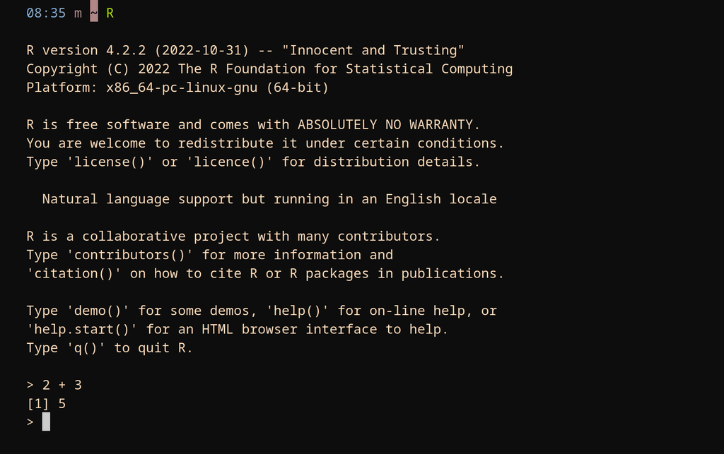

### RStudio

[Posit](https://posit.co/) (formerly RStudio Inc.) developed a great and very popular IDE called [RStudio](https://posit.co/download/rstudio-desktop/)

Here is its cheatsheet (click on it to download it):

[figure not shown]

from Posit Cheatsheets

# A few basics

## Documentation

The R documentation is excellent. Get info on any function with `?` (e.g. `?sum`)

## Basic operations

```r
a <- 5
4 + a
```

```
[1] 9
```

```r
c <- c(2, 4, 1)
c * 5
```

```
[1] 10 20  5
```

```r
sum(c)
```

```
[1] 7
```

## Statistics, probabilities, and modelling

R really shines when it comes to statistics and modelling

We will spend the rest of the hour diving into very complex and heavy Bayesian statistics

## Just kidding 🙂

In this demo, I will stick to fun topics

# Data visualization

## Datasets

R comes with a number of datasets. You can get a list by running `data()`

## Datasets

The `ggplot2` package provides [additional ones](https://ggplot2.tidyverse.org/reference/#data), such as the `mpg` dataset:

```r
library(ggplot2)
head(mpg, 4)  # we are printing only the first 4 rows
```

```
# A tibble: 4 × 11
  manufacturer model displ  year   cyl trans      drv     cty   hwy fl
  <chr>        <chr> <dbl> <int> <int> <chr>      <chr> <int> <int> <chr>
1 audi         a4      1.8  1999     4 auto(l5)   f        18    29 p
2 audi         a4      1.8  1999     4 manual(m5) f        21    29 p
3 audi         a4      2    2008     4 manual(m6) f        20    31 p
4 audi         a4      2    2008     4 auto(av)   f        21    30 p
  class
  <chr>
1 compact
2 compact
3 compact
4 compact
```

## The canvas

The first component is the data:

```r
ggplot(data = mpg)
```

[output not shown]

## The canvas

The second component sets the way variables are mapped on the axes. This is done with the `aes()` (aesthetics) function:

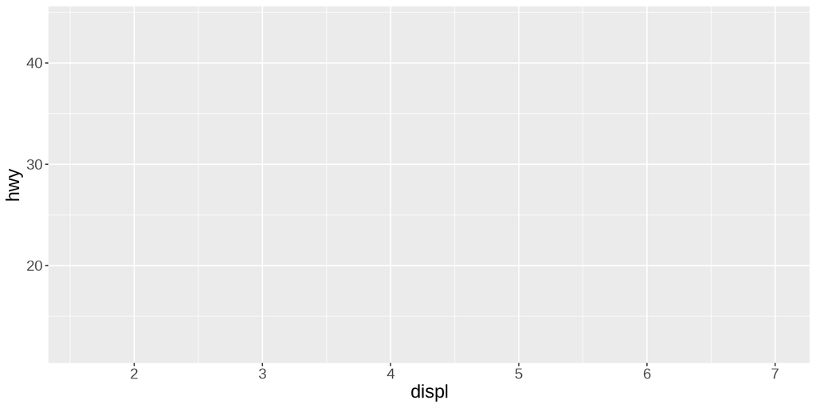

```r
ggplot(data = mpg, mapping = aes(x = displ, y = hwy))
```

## Geometric representations of the data

Onto this canvas, we can add “geoms” (geometrical objects) representing the data.  
To represent the data as a scatterplot, we use the `geom_point()` function:

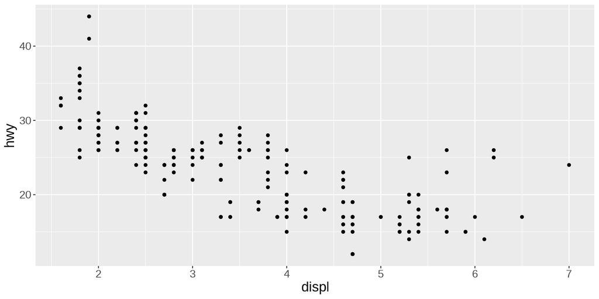

```r
ggplot(mpg, aes(x = displ, y = hwy)) +
  geom_point()
```

## Colour-coding based on variables

We can colour-code the points in the scatterplot based on the `drv` variable, showing the lower fuel efficiency of 4WD vehicles:

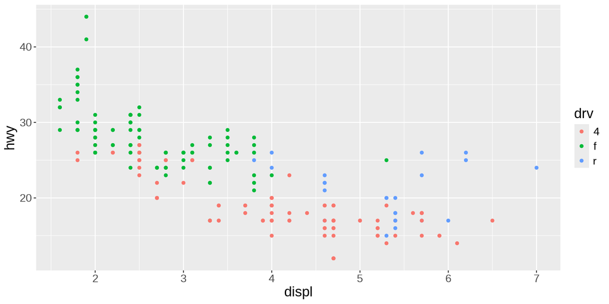

```r
ggplot(mpg, aes(x = displ, y = hwy)) +
  geom_point(aes(color = drv))
```

## Colour-coding based on variables

Or we can colour-code them based on the `class` variable:

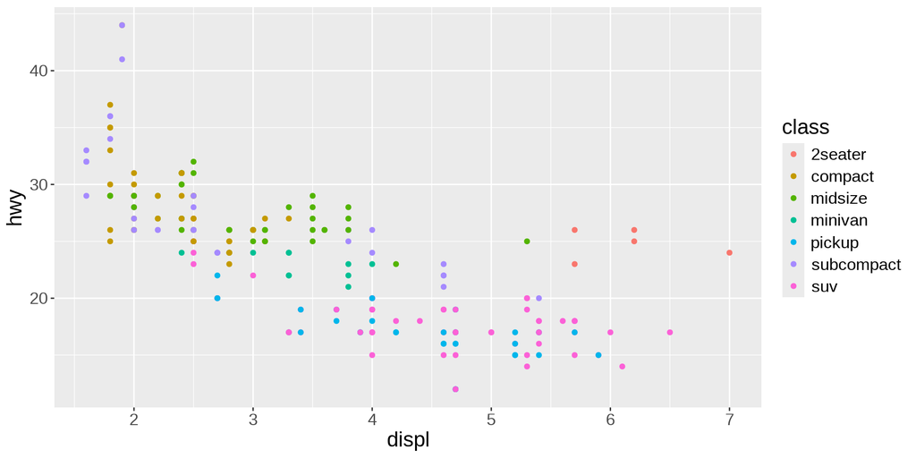

```r
ggplot(mpg, aes(x = displ, y = hwy)) +
  geom_point(aes(color = class))
```

## Multiple geoms

Multiple “geoms” can be added on top of each other. For instance, we can add a smoothed conditional means function that aids at seeing patterns in the data with `geom_smooth()`:

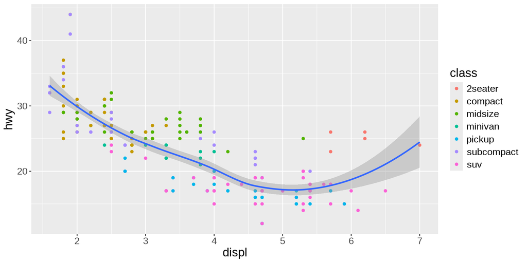

```r
ggplot(mpg, aes(x = displ, y = hwy)) +
  geom_point(aes(color = class)) +
  geom_smooth()
```

The default smoothing function uses the LOESS (locally estimated scatterplot smoothing) method. We can change the method by passing it as an argument to `geom_smooth()`:

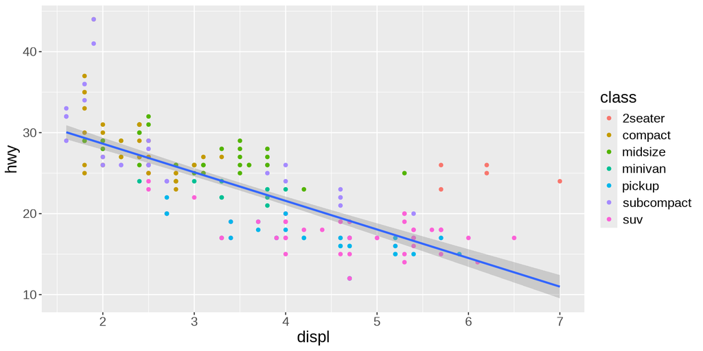

```r
ggplot(mpg, aes(x = displ, y = hwy)) +
  geom_point(aes(color = class)) +
  geom_smooth(method = lm)
```

We can apply the smoothing function to each class instead of the entire data. It creates a busy plot but shows that the downward trend remains true within each type of car:

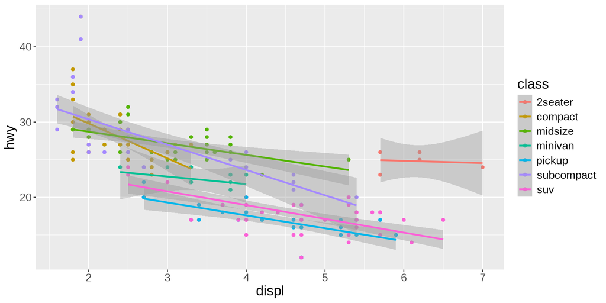

```r
ggplot(mpg, aes(x = displ, y = hwy, color = class)) +
  geom_point(aes(color = class)) +
  geom_smooth(method = lm)
```

We can remove the standard errors and customize the line for our linear model:

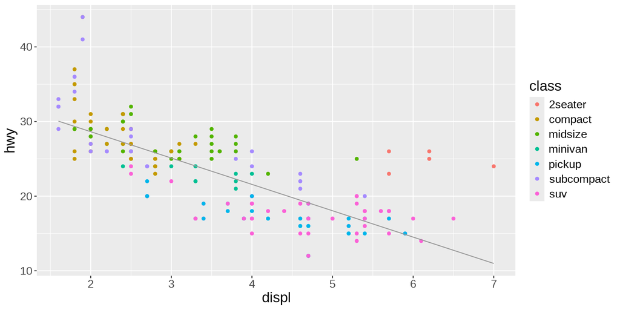

```r
ggplot(mpg, aes(x = displ, y = hwy)) +
  geom_point(aes(color = class)) +
  geom_smooth(
    method = lm,
    se = FALSE,
    color = "#999999",
    linewidth = 0.5
  )
```

## Colour scales

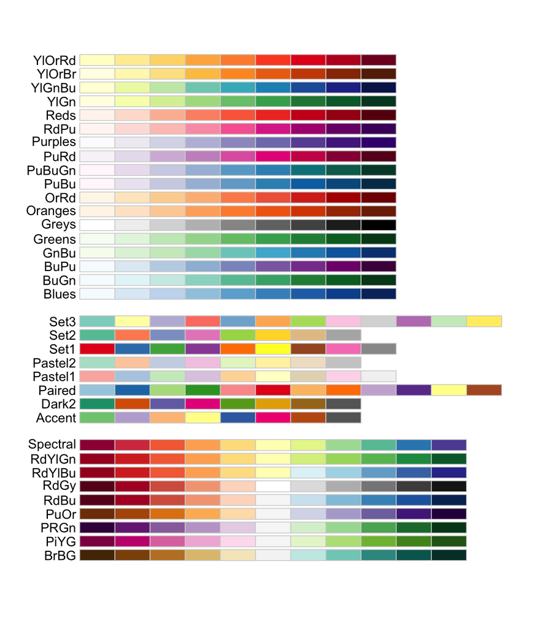

Let’s try the `Dark2` palette:

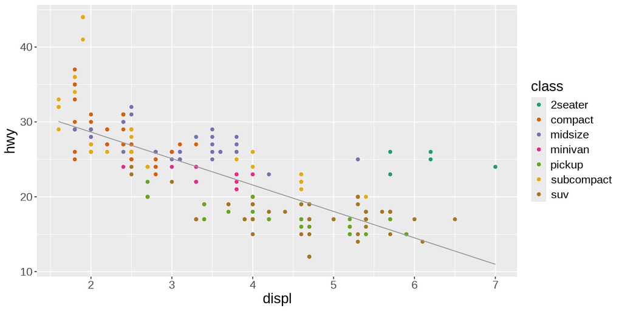

```r
ggplot(mpg, aes(x = displ, y = hwy)) +
  geom_point(aes(color = class)) +
  scale_color_brewer(palette = "Dark2") +
  geom_smooth(
    method = lm,
    se = FALSE,
    color = "#999999",
    linewidth = 0.5
  )
```

We can add title, axes labels, captions…

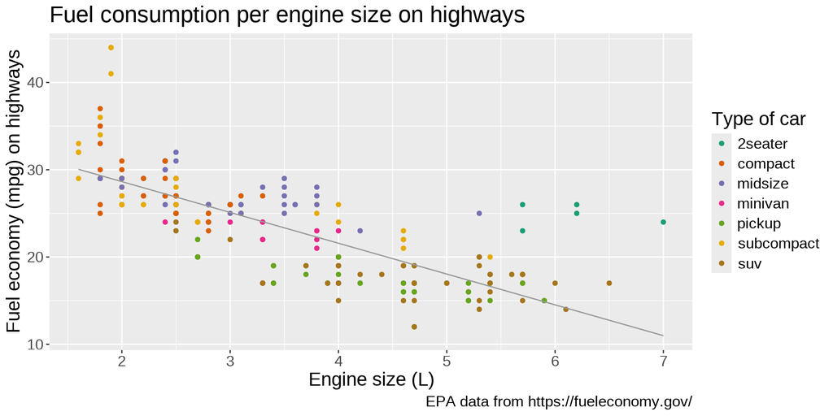

```r
ggplot(mpg, aes(x = displ, y = hwy)) +
  geom_point(aes(color = class)) +
  scale_color_brewer(palette = "Dark2") +
  geom_smooth(
    method = lm,
    se = FALSE,
    color = "#999999",
    linewidth = 0.5
  ) +
  labs(
    title = "Fuel consumption per engine size on highways",
    x = "Engine size (L)",
    y = "Fuel economy (mpg) on highways",
    color = "Type of car",
    caption = "EPA data from https://fueleconomy.gov/"
  )
```

Let’s change the theme to remove all this background noise:

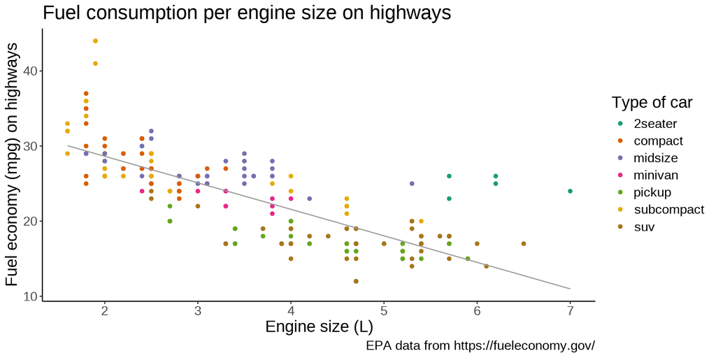

```r
ggplot(mpg, aes(x = displ, y = hwy)) +
geom_point(aes(color = class)) +
  scale_color_brewer(palette = "Dark2") +
  geom_smooth(
    method = lm,
    se = FALSE,
    color = "#999999",
    linewidth = 0.5
  ) +
  labs(
    title = "Fuel consumption per engine size on highways",
    x = "Engine size (L)",
    y = "Fuel economy (mpg) on highways",
    color = "Type of car",
    caption = "EPA data from https://fueleconomy.gov/"
  ) +
  theme_classic()
```

The `theme()` function allows you to tweak the theme in any number of ways. For instance, what if we don’t like the default position of the title and we’d rather have it centered?

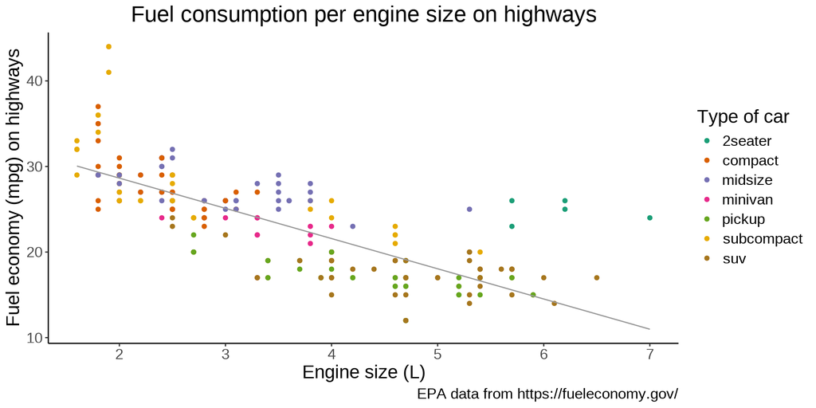

```r
ggplot(mpg, aes(x = displ, y = hwy)) +
geom_point(aes(color = class)) +
  scale_color_brewer(palette = "Dark2") +
  geom_smooth(
    method = lm,
    se = FALSE,
    color = "#999999",
    linewidth = 0.5
  ) +
  labs(
    title = "Fuel consumption per engine size on highways",
    x = "Engine size (L)",
    y = "Fuel economy (mpg) on highways",
    color = "Type of car",
    caption = "EPA data from https://fueleconomy.gov/"
  ) +
  theme_classic() +
  theme(plot.title = element_text(hjust = 0.5))
```

Many things can be changed thanks to the `theme()` function. For instance, we can move the legend to give more space to the actual graph:

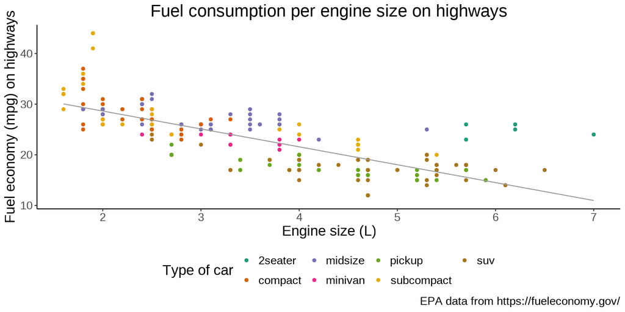

```r
ggplot(mpg, aes(x = displ, y = hwy)) +
geom_point(aes(color = class)) +
  scale_color_brewer(palette = "Dark2") +
  geom_smooth(
    method = lm,
    se = FALSE,
    color = "#999999",
    linewidth = 0.5
  ) +
  labs(
    title = "Fuel consumption per engine size on highways",
    x = "Engine size (L)",
    y = "Fuel economy (mpg) on highways",
    color = "Type of car",
    caption = "EPA data from https://fueleconomy.gov/"
  ) +
  theme_classic() +
  theme(plot.title = element_text(hjust = 0.5), legend.position = "bottom")
```

## ggplot extensions

[Many packages](https://exts.ggplot2.tidyverse.org/gallery/) build on `ggplot2` and add functionality

## Combining plots

One ggplot extension is the [patchwork](https://patchwork.data-imaginist.com/) package which allows you to combine multiple plots on the same frame

Let’s add a second plot next to our plot (we also make a few changes to the labels to improve the plots’ integration):

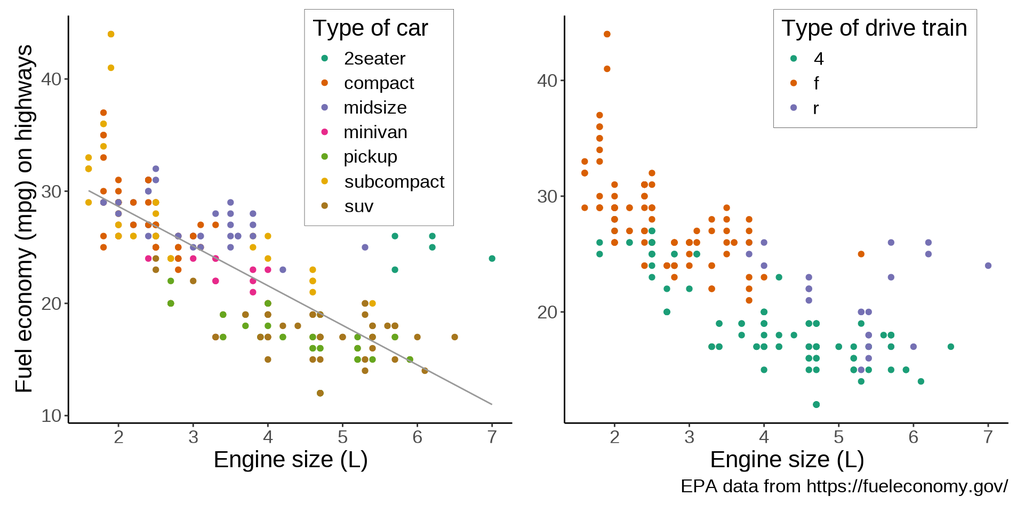

```r
library(patchwork)

ggplot(mpg, aes(x = displ, y = hwy)) +        # First plot
  geom_point(aes(color = class)) +
  scale_color_brewer(palette = "Dark2") +
  geom_smooth(
    method = lm,
    se = FALSE,
    color = "#999999",
    linewidth = 0.5
  ) +
  labs(
    x = "Engine size (L)",
    y = "Fuel economy (mpg) on highways",
    color = "Type of car"
  ) +
  theme_classic() +
  theme(
    plot.title = element_text(hjust = 0.5),
    legend.position = c(0.7, 0.75),           # Better legend position
    legend.background = element_rect(         # Add a frame to the legend
      linewidth = 0.1,
      linetype = "solid",
      colour = "black"
    )
  ) +
  ggplot(mpg, aes(x = displ, y = hwy)) +      # Second plot
  geom_point(aes(color = drv)) +
  scale_color_brewer(palette = "Dark2") +
  labs(
    x = "Engine size (L)",
    y = element_blank(),                      # Remove redundant label
    color = "Type of drive train",
    caption = "EPA data from https://fueleconomy.gov/"
  ) +
  theme_classic() +
  theme(
    plot.title = element_text(hjust = 0.5),
    legend.position = c(0.7, 0.87),
    legend.background = element_rect(
      linewidth = 0.1,
      linetype = "solid",
      colour = "black"
    )
  )
```

# Web scraping

## HTML and CSS

[HyperText Markup Language](https://en.wikipedia.org/wiki/HTML) (HTML) is the standard markup language for websites: it encodes the information related to the formatting and structure of webpages. Additionally, some of the customization can be stored in [Cascading Style Sheets](https://en.wikipedia.org/wiki/CSS) (CSS) files.

HTML uses tags of the form:

```html
<some_tag>Your content</some_tag>
```

Some tags have attributes:

```html
<some_tag attribute_name="attribute value">Your content</some_tag>
```

Examples:

- `<h2>This is a heading of level 2</h2>`
- `<b>This is bold</b>`
- `<a href="https://some.url">This is the text for a link</a>`

## Example for this workshop

We will use [a website](https://trace.tennessee.edu/utk_graddiss/index.html) from the [University of Tennessee](https://www.utk.edu/) containing a database of PhD theses from that university

Our goal is to scrape data from this site to produce a dataframe with the date, major, and advisor for each dissertation

## Package

To do all this, we will use the package [rvest](https://cran.r-project.org/web/packages/rvest/index.html), part of the [tidyverse](https://www.tidyverse.org/) (a modern set of R packages). It is a package influenced by the popular Python package Beautiful Soup and it makes scraping websites with R really easy

Let’s load it:

```r
library(rvest)
```

## Read in HTML from main site

Our site is the [database of PhD dissertations from the University of Tennessee](https://trace.tennessee.edu/utk_graddiss/index.html)

Let’s create a character vector with the URL:

```r
url <- "https://trace.tennessee.edu/utk_graddiss/index.html"
```

First, we read in the html data from that page:

```r
html <- read_html(url)
```

Let’s have a look at the raw data:

```r
html
```

```
{html_document}
<html lang="en">
[1] <head>\n<meta http-equiv="Content-Type" content="text/html; charset=UTF-8 ...
[2] <body>\n<!-- FILE /srv/sequoia/main/data/trace.tennessee.edu/assets/heade ...
```

## Extract all URLs

```r
dat <- html %>% html_elements(".article-listing a")
dat[1:6]
```

```
{xml_nodeset (6)}
[1] <a href="https://trace.tennessee.edu/utk_graddiss/12328">Essays in Macroe ...
[2] <a href="https://trace.tennessee.edu/utk_graddiss/12671">UNDERSTANDING AN ...
[3] <a href="https://trace.tennessee.edu/utk_graddiss/12672">Soil Nitrous Oxi ...
[4] <a href="https://trace.tennessee.edu/utk_graddiss/12329">CHARACTERIZATION ...
[5] <a href="https://trace.tennessee.edu/utk_graddiss/12330">View from the To ...
[6] <a href="https://trace.tennessee.edu/utk_graddiss/12331">Exploration of V ...
```

## Extract all URLs

We now have a list of lists

Before running for loops, it is important to initialize empty loops. It is much more efficient than growing the result at each iteration

So let’s initialize an empty list that we call `list_urls` of the appropriate size:

```r
list_urls <- vector("list", length(dat))
```

[output not shown]

## Extract all URLs

Now we can run a loop to fill in our list:

```r
for (i in seq_along(dat)) {
  list_urls[[i]] <- dat[[i]] %>% html_attr("href")
}
```

Let’s print again the first element of `list_urls` to make sure all looks good:

```r
list_urls[[1]]
```

[output not shown]

We now have a list of URLs (in the form of character vectors) as we wanted

## Extract data from each page

We will now extract the data (date, major, and advisor) for all URLs in our list.

Again, before running a for loop, we need to allocate memory first by creating an empty container (here a list):

## Extract data from each page

```r
list_data <- vector("list", length(list_urls))

for (i in seq_along(list_urls)) {
  html <- read_html(list_urls[[i]])
  date <- html %>%
    html_element("#publication_date p") %>%
    html_text2()
  major <- html %>%
    html_element("#department p") %>%
    html_text2()
  advisor <- html %>%
    html_element("#advisor1 p") %>%
    html_text2()
  Sys.sleep(0.1)  # Add a little delay
  list_data[[i]] <- cbind(date, major, advisor)
}
```

## Store results in DataFrame

We can turn this big list into a dataframe:

```r
result <- do.call(rbind.data.frame, list_data)
```

We can capitalize the headers:

```r
names(result) <- c("Date", "Major", "Advisor")
```

## Our final data

`result` is a long dataframe, so we will only print the first few elements:

```r
head(result, 6)
```

```
    Date                                           Major               Advisor
1 5-2025                                       Economics     Andrew, S, Hanson
2 8-2025                               Civil Engineering Nicholas E. Wierschem
3 8-2025          Plant, Soil and Environmental Sciences         Debasish Saha
4 5-2025 Biochemistry and Cellular and Molecular Biology              Jae Park
5 5-2025                 Higher Education Administration       Pamella Angelle
6 5-2025                                            <NA>        Andrea S. Lear
```

## Save results to file

If we wanted, we could save our data to a CSV file:

```r
write.csv(result, "dissertations_data.csv", row.names = FALSE)
```

# GIS mapping

## Data reading and manipulation

- Spatial vectors: great modern packages are sf or terra
- Raster data: the package terra

I will skip the data preparation due to lack of time, but you can look at the code in this webinar or this workshop

## Mapping data

Good options to create maps include ggplot2 (the package we already used for plotting) or tmap

## Map of glaciers in western North America

```r
tm_shape(states, bbox = nwa_bbox) +
  tm_polygons(col = "#f2f2f2", lwd = 0.2) +
  tm_shape(ak) +
  tm_borders(col = "#3399ff") +
  tm_fill(col = "#86baff") +
  tm_shape(wes) +
  tm_borders(col = "#3399ff") +
  tm_fill(col = "#86baff") +
  tm_layout(
    title = "Glaciers of Western North America",
    title.position = c("center", "top"),
    title.size = 1.1,
    bg.color = "#fcfcfc",
    inner.margins = c(0.06, 0.01, 0.09, 0.01),
    outer.margins = 0,
    frame.lwd = 0.2
  ) +
  tm_compass(
    type = "arrow",
    position = c("right", "top"),
    size = 1.2,
    text.size = 0.6
  ) +
  tm_scale_bar(
    breaks = c(0, 1000, 2000),
    position = c("right", "BOTTOM")
  )
```

[figure not shown]